# Final

2023-04-11

```r
#Load and Install Packages
library(tidyverse)
library(tidytuesdayR)
library(haven)
library(dataReporter)
```

```r
library(ggplot2)
library(dplyr)
library(gtsummary)
library(gt)
library(RSQLite)
```

Get Data and convert .sav to .csv

```r
#We started off initially with a .sav file for our data and needed to convert this below:

# Read the .sav file into df
#df <- read_sav("YALE0065_OUTPUT.sav")

# Save the df as an .rds file
#saveRDS(df, "YALE0065_OUTPUT.rds")

# Read the .rds file back into a data frame
df0 <- readRDS("YALE0065_OUTPUT.rds")
```

Cleaning data

```r
df1 <- subset(df0, select = c(educ, gender, Q1_9, Q2_9) )
df1 <- na.omit(df1)
```

Looking at the current data frame

```r
summary(df1)
```

```
##       educ           gender           Q1_9            Q2_9
##  Min.   :1.000   Min.   :1.000   Min.   : 1.00   Min.   :1.000
##  1st Qu.:2.000   1st Qu.:1.000   1st Qu.: 7.00   1st Qu.:6.000
##  Median :3.000   Median :2.000   Median :99.00   Median :9.000
##  Mean   :3.401   Mean   :1.524   Mean   :71.81   Mean   :7.469
##  3rd Qu.:5.000   3rd Qu.:2.000   3rd Qu.:99.00   3rd Qu.:9.000
##  Max.   :6.000   Max.   :2.000   Max.   :99.00   Max.   :9.000
```

```r
print(df1)
```

```
## # A tibble: 2,000 × 4
##    educ             gender     Q1_9                           Q2_9
##    <dbl+lbl>        <dbl+lbl>  <dbl+lbl>                      <dbl+lbl>
##  1 4 [2-year]       2 [Female] 99 [not asked]                 9 [not asked]
##  2 6 [Post-grad]    1 [Male]   99 [not asked]                 9 [not asked]
##  3 4 [2-year]       2 [Female] 99 [not asked]                 9 [not asked]
##  4 4 [2-year]       2 [Female] 99 [not asked]                 9 [not asked]
##  5 3 [Some college] 1 [Male]   99 [not asked]                 9 [not asked]
##  6 4 [2-year]       1 [Male]   99 [not asked]                 9 [not asked]
##  7 3 [Some college] 2 [Female]  5 [Somewhat likely  60-80%]   5 [Catastrophic]
##  8 6 [Post-grad]    1 [Male]    3 [Somewhat unlikely  20-40%] 3 [Moderate]
##  9 5 [4-year]       1 [Male]   99 [not asked]                 9 [not asked]
## 10 5 [4-year]       1 [Male]   99 [not asked]                 9 [not asked]
## # … with 1,990 more rows
```

Cleaning the data

```r
# Remove observations that are: "I don't know", "skipped" or "not asked".
df1<- df1 %>% filter(Q1_9 < 98) %>%
  filter(Q2_9 < 6) %>%
  filter(educ < 7)
```

Wrangling the data

```r
# Make variables into numeric

df1$gender <- as.numeric(df1$gender)
df1$educ <- as.numeric(df1$educ)
df1$Q1_9 <- as.numeric(df1$Q1_9)
df1$Q2_9 <- as.numeric(df1$Q2_9)
```

Recoding Variables

```r
# Recode gender
df1 <- df1 %>%
  mutate(gender = case_when(
    gender == 1 ~ "Male",
    gender == 2 ~ "Female",
    TRUE ~ as.character(gender)  # Keep other values unchanged
  ))


# Recode Q1_9
df1 <- df1 %>%
  mutate(Q1_9 = case_when(
    Q1_9 == 1 ~ "Very Unlikely",
    Q1_9 == 2 ~ "Unlikely",
    Q1_9 == 3 ~ "Somewhat Unlikely",
    Q1_9 == 4 ~ "Equally Likely as Unlikely",
    Q1_9 == 5 ~ "Somewhat Likely",
    Q1_9 == 6 ~ "Likely",
    Q1_9 == 7 ~ "Very Likely"
  ))

# Recode Q2_9
df1 <- df1 %>%
  mutate(Q2_9 = case_when(
    Q2_9 == 1 ~ "Minimal",
    Q2_9 == 2 ~ "Minor",
    Q2_9 == 3 ~ "Moderate",
    Q2_9 == 4 ~ "Severe",
    Q2_9 == 5 ~ "Catastrophic"
  ))

# Recode educ
df1 <- df1 %>%
  mutate(educ = case_when(
    educ == 1 ~ "No HS",
    educ == 2 ~ "HS Graduate",
    educ == 3 ~ "Some College",
    educ == 4 ~ "2-Year College",
    educ == 5 ~ "4-Year College",
    educ == 6 ~ "Post-Grad"
  ))
```

But! We need a variable with numeric class for the y axis of the boxplot

```r
#Create new variables:

df1$Q1numeric <- df1$Q1_9
df1$Q2numeric <- df1$Q2_9


# Recode new variable Q1numeric into this scale
df1 <- df1 %>%
  mutate(Q1numeric = case_when(
    Q1numeric == "Very Unlikely" ~ -3,
    Q1numeric == "Unlikely" ~ -2,
    Q1numeric == "Somewhat Unlikely" ~ -1,
    Q1numeric == "Equally Likely as Unlikely" ~ 0,
    Q1numeric == "Somewhat Likely" ~ 1,
    Q1numeric == "Likely" ~ 2,
    Q1numeric == "Very Likely" ~ 3
  ))

# Recode new variable Q2numeric into this scale
df1 <- df1 %>%
  mutate(Q2numeric = case_when(
    Q2numeric == "Minimal" ~ -2,
    Q2numeric == "Minor" ~ -1,
    Q2numeric == "Moderate" ~ 0,
    Q2numeric == "Severe" ~ 1,
    Q2numeric == "Catastrophic" ~ 2
  ))

#Making sure the new variables are numeric

df1$Q1numeric <- as.numeric(df1$Q1numeric)
df1$Q2numeric <- as.numeric(df1$Q2numeric)
df1 <- na.omit(df1)
```

Summary Statistics

```r
## Using gtsummary for summary statistics

df2 <- df1 %>% select(gender, educ, Q1_9, Q2_9)
table1 <- tbl_summary(df2)
gt_table1 <- as_gt(table1)

#Incurred issue with this table displaying on html version. Fixing below:
# Convert the gt_summary object to a data frame
gt_table1_df <- as.data.frame(gt_table1)

# Convert the data frame to a gt object
gt_table1 <- gt(gt_table1_df)

# Render the table and display it in the output
gt_table1
```

| variable | var_type | var_label | row_type | label | stat_0 |
| --- | --- | --- | --- | --- | --- |
| gender | categorical | gender | label | gender |  |
| gender | categorical | gender | level | Female | 268 (55%) |
| gender | categorical | gender | level | Male | 216 (45%) |
| educ | categorical | educ | label | educ |  |
| educ | categorical | educ | level | 2-Year College | 48 (9.9%) |
| educ | categorical | educ | level | 4-Year College | 107 (22%) |
| educ | categorical | educ | level | HS Graduate | 142 (29%) |
| educ | categorical | educ | level | No HS | 32 (6.6%) |
| educ | categorical | educ | level | Post-Grad | 47 (9.7%) |
| educ | categorical | educ | level | Some College | 108 (22%) |
| Q1_9 | categorical | Q1_9 | label | Q1_9 |  |
| Q1_9 | categorical | Q1_9 | level | Equally Likely as Unlikely | 105 (22%) |
| Q1_9 | categorical | Q1_9 | level | Likely | 44 (9.1%) |
| Q1_9 | categorical | Q1_9 | level | Somewhat Likely | 62 (13%) |
| Q1_9 | categorical | Q1_9 | level | Somewhat Unlikely | 86 (18%) |
| Q1_9 | categorical | Q1_9 | level | Unlikely | 86 (18%) |
| Q1_9 | categorical | Q1_9 | level | Very Likely | 43 (8.9%) |
| Q1_9 | categorical | Q1_9 | level | Very Unlikely | 58 (12%) |
| Q2_9 | categorical | Q2_9 | label | Q2_9 |  |
| Q2_9 | categorical | Q2_9 | level | Catastrophic | 82 (17%) |
| Q2_9 | categorical | Q2_9 | level | Minimal | 43 (8.9%) |
| Q2_9 | categorical | Q2_9 | level | Minor | 79 (16%) |
| Q2_9 | categorical | Q2_9 | level | Moderate | 158 (33%) |
| Q2_9 | categorical | Q2_9 | level | Severe | 122 (25%) |

Plotting

```r
## Setting a theme:

theme_set(
  theme_classic() +
    theme(legend.position = "top")
  )
```

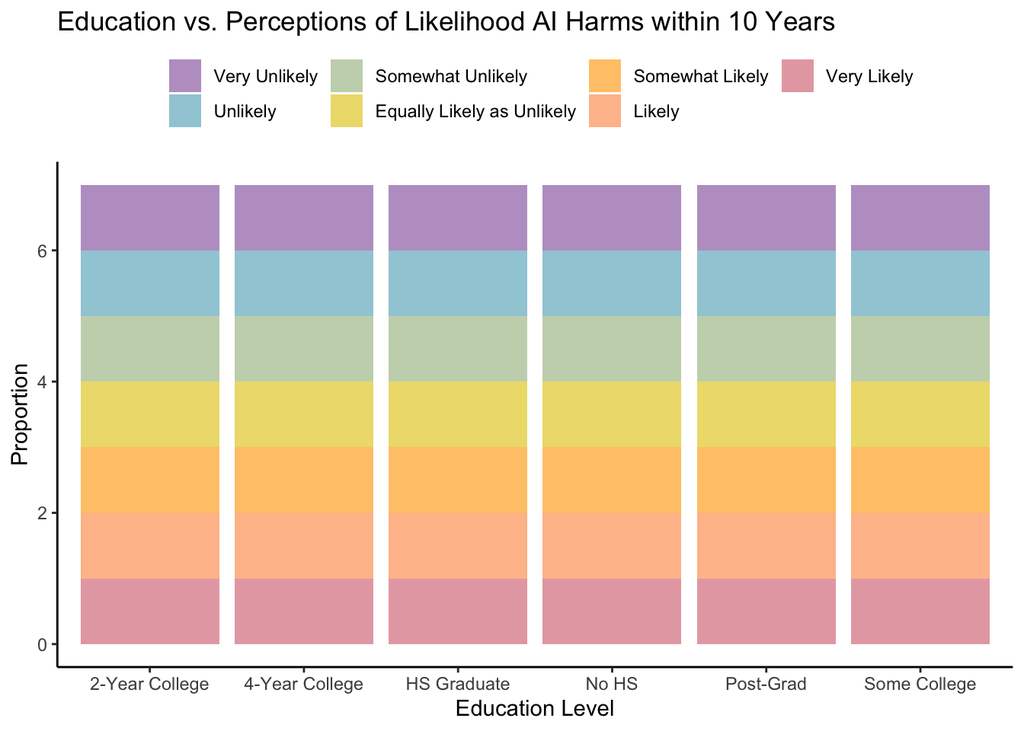

```r
## Q1_9:

#Create prop variable for Q1_9: proportion or percentage of respondents in each education level for different levels of fear of AI.
Q1Prop <- df1 %>%
  group_by(educ, Q1_9) %>%
  summarise(count = n(), .groups = "keep") %>%
  mutate(prop = count / sum(count))


#Now to go on to the plotting of Q1_9 in stacked bar graph

#First reorder the education observations on x axis
Q1Prop<- Q1Prop %>%
   mutate(educ = fct_relevel(educ,
            "No HS","HS Graduate","Some College","2-Year College","4-Year College", "Post-Grad"))
#Then reorder the legend

Q1Prop$Q1_9 <- factor(Q1Prop$Q1_9, levels = c("Very Unlikely", "Unlikely", "Somewhat Unlikely", "Equally Likely as Unlikely", "Somewhat Likely", "Likely", "Very Likely"))

#Then the actual plot for Q1_9
plot1 <-ggplot(Q1Prop, aes(x = educ, y = prop, fill = factor(Q1_9))) +
  geom_bar(stat = "identity", position = "stack") +
  scale_fill_manual(values = c("Very Unlikely" = "#BDA0CB", "Unlikely" = "#A0CDD9",
                                "Somewhat Unlikely" = "#C8D5B9", "Equally Likely as Unlikely" = "#EEDD7B", "Somewhat Likely"="#FFC777", "Likely"= "#FEBF99", "Very Likely"="#E6A9B1", "NA" = "grey68")) +
  labs(title = "Education vs. Perceptions of Likelihood AI Harms within 10 Years",
       x = "Education Level",
       y = "Proportion",
        fill= "")
plot1
```

```r
ggsave("plot1.png", height=6, width=8)
```

```r
#Create prop variable for Q2_9: proportion or percentage of respondents in each education level for different levels of fear of AI.
Q2Prop <- df1 %>%
  group_by(educ, Q2_9) %>%
  summarise(count = n(), .groups = "keep") %>%
  mutate(prop = count / sum(count))


#Also reorder the education observations for Q2Prop
Q2Prop<- Q2Prop %>%
   mutate(educ = fct_relevel(educ,
            "No HS","HS Graduate","Some College","2-Year College","4-Year College", "Post-Grad"))
```

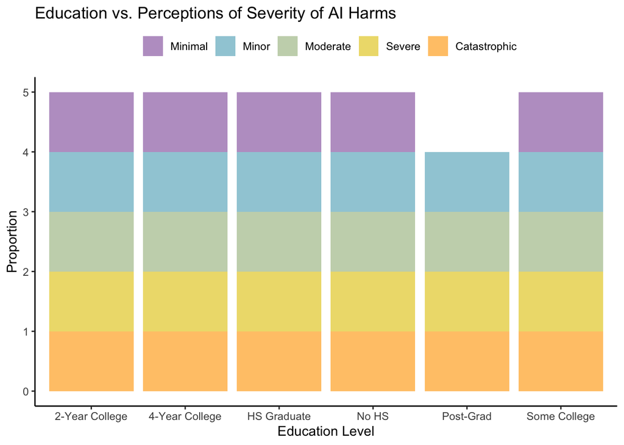

```r
#Reorder the legend

Q2Prop$Q2_9 <- factor(Q2Prop$Q2_9, levels = c("Minimal", "Minor", "Moderate", "Severe", "Catastrophic"))

#The actual plot for Q2_9
plot2 <- ggplot(Q2Prop, aes(x = educ, y = prop, fill = factor(Q2_9))) +
  geom_bar(stat = "identity", position = "stack") +
 scale_fill_manual(values = c("Minimal" = "#BDA0CB", "Minor" = "#A0CDD9",
                                "Moderate" = "#C8D5B9", "Severe" = "#EEDD7B", "Catastrophic"="#FFC777"))+
  labs(title = "Education vs. Perceptions of Severity of AI Harms",
       x = "Education Level",
       y = "Proportion",
       fill= "")

plot2
```

```r
ggsave("plot2.png", height=6, width=8)
```

Now we want to see how gender map onto this relationship using box plot. Below is how gender maps pnto the relationship between education level and likelihood of AI harms within 10 years.

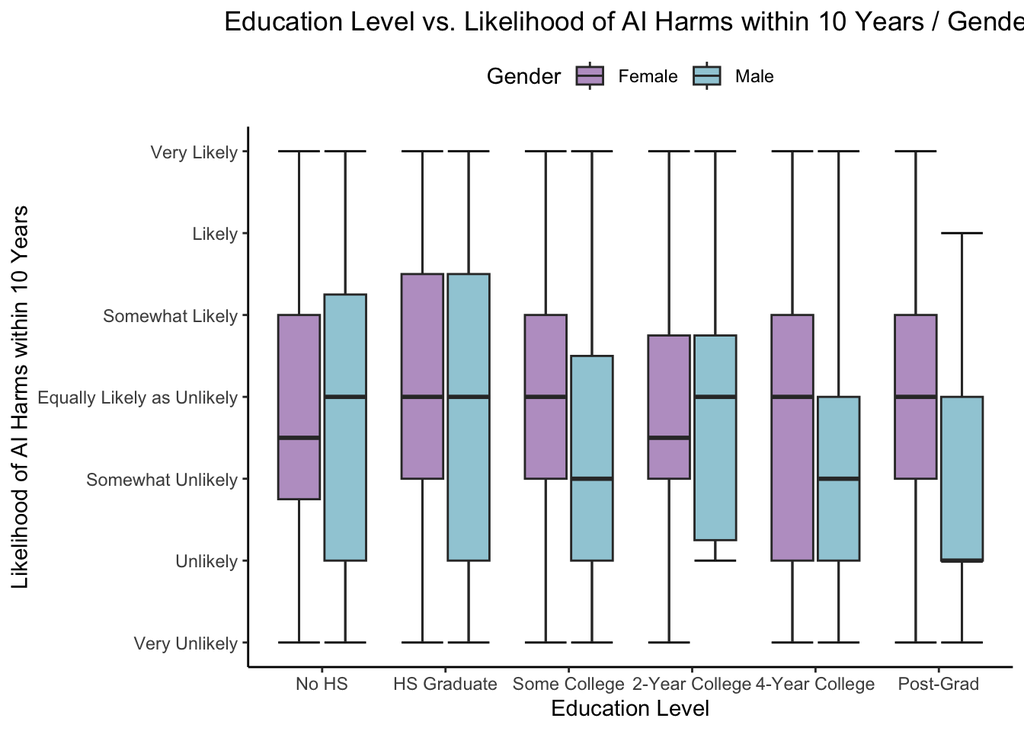

```r
#Reorder the educ variable
df1 <- df1 %>%
   mutate(educ = fct_relevel(educ,
            "No HS","HS Graduate","Some College","2-Year College","4-Year College", "Post-Grad"))

#Create y axis values to better understand plot
custom_y_labels <- c("Very Unlikely", "Unlikely", "Somewhat Unlikely", "Equally Likely as Unlikely", "Somewhat Likely", "Likely", "Very Likely")


#Plot


box1 <- ggplot(df1, aes(x = educ, y = Q1numeric, fill = gender)) +
  stat_boxplot(geom = "errorbar")+
  geom_boxplot() +
  labs(title = "Education Level vs. Likelihood of AI Harms within 10 Years / Gender",
       x = "Education Level",
       y = "Likelihood of AI Harms within 10 Years",
       fill = "Gender")+
    scale_y_continuous(breaks = c(-3,-2,-1,0,1,2,3), labels = custom_y_labels)+
  scale_fill_manual(values = c("Female" = "#BDA0CB", "Male" = "#A0CDD9"))+
  theme(plot.title = element_text(hjust = 0.5))

box1
```

```r
ggsave("box1.png", height=6, width=8)
```

We do the same for mapping gender onto the relationship between education level and severity of AI harms.

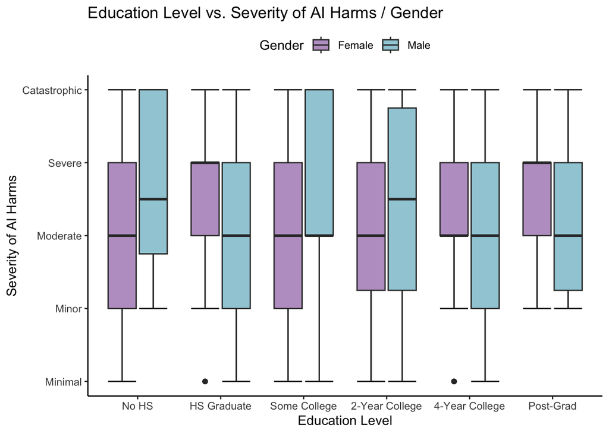

```r
#First need to create the labels for y axis values to better understand plot
custom_y_labels2 <- c("Minimal", "Minor", "Moderate", "Severe", "Catastrophic")

#Plot

box2 <- ggplot(df1, aes(x = educ, y = Q2numeric, fill = gender)) +
  stat_boxplot(geom = "errorbar")+
  geom_boxplot() +
  labs(title = "Education Level vs. Severity of AI Harms / Gender",
       x = "Education Level",
       y = "Severity of AI Harms",
       fill = "Gender")+
   scale_y_continuous(breaks = c(-2,-1,0,1,2), labels = custom_y_labels2)+
  scale_fill_manual(values = c("Female" = "#BDA0CB", "Male" = "#A0CDD9"))

box2
```

```r
ggsave("box2.png", height=6, width=8)
```